# working with python string.

```python
sentence="The quick brown fox jumps over the lazy dog."
```

```python
sentence
```

```
'The quick brown fox jumps over the lazy dog.'
```

```python
sentence.index('fox')
```

```
16
```

```python
sentence.split().index("lazy")
```

```
7
```

```python
sentence.split()[2]
```

```
'brown'
```

```python
sentence.split()[2][::-1]
```

```
'nworb'
```

```python
sentence.split()[-1]
```

```
'dog.'
```

```python
word=sentence.split()
first_word=word[0]
last_word=word[-1]
combined_words=first_word+last_word
```

```python
print(combined_words)
```

```
Thedog.
```

```python
[word[w] for w in range(len(word)) if w%2!=0]
```

```
['quick', 'fox', 'over', 'lazy']
```

```python
[word[w] for w in range(len(word)) if w%2==0]
```

```
['The', 'brown', 'jumps', 'the', 'dog.']
```

```python
sentence[-4:]
```

```
'dog.'
```

```python
sentence[::-1]
```

```
'.god yzal eht revo spmuj xof nworb kciuq ehT'
```

```python
[' '.join([w[::-1] for w in word  ])]
```

```
['ehT kciuq nworb xof spmuj revo eht yzal .god']
```

# nltk

```python
import nltk
from nltk import word_tokenize
nltk.download('punkt')
```

```
True
```

```python
sent=word_tokenize("I am doing coding exercise in NLP")
```

```python
print(sent)
```

```
['I', 'am', 'doing', 'coding', 'exercise', 'in', 'NLP']
```

```python
nltk.download('averaged_perceptron_tagger')
nltk.pos_tag(sent)
```

```
[('I', 'PRP'),
 ('am', 'VBP'),
 ('doing', 'VBG'),
 ('coding', 'VBG'),
 ('exercise', 'NN'),
 ('in', 'IN'),
 ('NLP', 'NNP')]
```

```python
nltk.download('stopwords')
from nltk.corpus import stopwords
```

```python
stop_word=stopwords.words("English")
```

```python
print(stop_word)
```

```
['i', 'me', 'my', 'myself', 'we', 'our', 'ours', 'ourselves', 'you', "you're", "you've", "you'll", "you'd", 'your', 'yours', 'yourself', 'yourselves', 'he', 'him', 'his', 'himself', 'she', "she's", 'her', 'hers', 'herself', 'it', "it's", 'its', 'itself', 'they', 'them', 'their', 'theirs', 'themselve…
```

```python
sent="I am learning natural langauge process and machine learning. It is one of the popular job skills now"
```

```python
sent
```

```
'I am learning natural langauge process and machine learning. It is one of the popular job skills now'
```

```python
token_words=word_tokenize(sent)
```

```python
print(token_words)
```

```
['I', 'am', 'learning', 'natural', 'langauge', 'process', 'and', 'machine', 'learning', '.', 'It', 'is', 'one', 'of', 'the', 'popular', 'job', 'skills', 'now']
```

```python
no_stopword_sent=' '.join([w for w in token_words if w not in stop_word])
```

```python
print(no_stopword_sent)
```

```
I learning natural langauge process machine learning . It one popular job skills
```

## Text Normaliztion

```python
sent1="I visited US from UK on 22-10-18"
```

```python
new_sent=sent1.replace("US","United States").replace("UK","United Kingdom").replace("-18","-2018")
```

```python
new_sent
```

```
'I visited United States from United Kingdom on 22-10-2018'
```

## Spelling Corrections

```python
from autocorrect import spell
```

```python
w="wodr"
```

```python
spell(w)
```

```
'word'
```

```python
sent2=word_tokenize("I wsa doing thta honework from last nigth")
```

```python
sent2
```

```
['I', 'wsa', 'doing', 'thta', 'honework', 'from', 'last', 'nigth']
```

```python
correct_sent=' '.join([spell(s) for s in sent2])
```

```python
correct_sent
```

```
'I was doing that homework from last night'
```

```python
import nltk
from nltk import word_tokenize
nltk.download("maxent_ne_chunker")
nltk.download("words")
```

```
True
```

```python
sent3='We are reading a book published by Packt which is based out of Birmingham'
```

```python
i=nltk.ne_chunk(nltk.pos_tag(word_tokenize(sent3)),binary=True)
[a for a in i if len(a)==1]
```

```
[Tree('NE', [('Packt', 'NNP')]), Tree('NE', [('Birmingham', 'NNP')])]
```

## Word Sense Disambiguation

```python
from nltk.wsd import lesk
```

```python
s1='keep your savining in bank'
s2="It is so risky to drive over the banks of the road"
```

```python
print(lesk(word_tokenize(s1),'bank'))
```

```
Synset('bank.v.03')
```

```python
print(lesk(word_tokenize(s2),'bank'))
```

```
Synset('bank.n.07')
```

## Sentence Boundary Detection

```python
from nltk.tokenize import sent_tokenize
```

```python
sent_tokenize("We are reading a book. Do you know who is the publisher? It is Packt. Packt is based out of Birmingham")
```

```
['We are reading a book.',
 'Do you know who is the publisher?',
 'It is Packt.',
 'Packt is based out of Birmingham']
```

## Chapter 1 Exercise

```python
with open('file.txt')as f:
    doc=f.read()
```

```python
doc
```

```
'For the NSA, the relatively smooth handoff was a triumph. But the incident marked an important turning point, underlining how the NSA was collecting too much information for its facilities to handle. The agency would go on to build a massive data center in a barren stretch of Utah desert, estimated…
```

```python
first20_token=doc.split()[:20]
```

```python
print(first20_token)
```

```
['For', 'the', 'NSA,', 'the', 'relatively', 'smooth', 'handoff', 'was', 'a', 'triumph.', 'But', 'the', 'incident', 'marked', 'an', 'important', 'turning', 'point,', 'underlining', 'how']
```

```python
spell_check=[]
for i in first20_token:
    s=spell(i)
    spell_check.append(s)
print(spell_check)
```

```
['For', 'the', 'NSAP', 'the', 'relatively', 'smooth', 'handoff', 'was', 'a', 'triumph', 'But', 'the', 'incident', 'marked', 'an', 'important', 'turning', 'point', 'underlining', 'how']
```

```python
spell_chk=[spell(i) for i in first20_token]
print(spell_chk)
```

[output not shown]

```python
from nltk import word_tokenize
```

```python
nltk.pos_tag(spell_check)
```

```
[('For', 'IN'),
 ('the', 'DT'),
 ('NSAP', 'NNP'),
 ('the', 'DT'),
 ('relatively', 'RB'),
 ('smooth', 'JJ'),
 ('handoff', 'NN'),
 ('was', 'VBD'),
 ('a', 'DT'),
 ('triumph', 'NN'),
 ('But', 'CC'),
 ('the', 'DT'),
 ('incident', 'NN'),
 ('marked', 'VBD'),
 ('an', 'DT'),
 ('important', 'JJ'),
 ('turning', 'NN'),
 ('point', 'NN'),
 ('underlining', 'VBG'),
 ('how', 'WRB')]
```

```python
no_stop_sent=' '.join([w for w in spell_check if w not in stop_word])
```

```python
no_stop_sent
```

```
'For NSAP relatively smooth handoff triumph But incident marked important turning point underlining'
```

```python
stemmer=nltk.stem.PorterStemmer()
```

```python
stemm=[stemmer.stem(s) for s in spell_check]
```

```python
print(stemm)
```

```
['for', 'the', 'nsap', 'the', 'rel', 'smooth', 'handoff', 'wa', 'a', 'triumph', 'but', 'the', 'incid', 'mark', 'an', 'import', 'turn', 'point', 'underlin', 'how']
```

```python
from nltk.stem.wordnet import WordNetLemmatizer
```

```python
lemmat=WordNetLemmatizer()
```

```python
lemm=[lemmat.lemmatize(l) for l in spell_check]
```

```python
print(lemm)
```

```
['For', 'the', 'NSAP', 'the', 'relatively', 'smooth', 'handoff', 'wa', 'a', 'triumph', 'But', 'the', 'incident', 'marked', 'an', 'important', 'turning', 'point', 'underlining', 'how']
```

```python
join=' '.join(spell_check)
print(join)
```

```
For the NSAP the relatively smooth handoff was a triumph But the incident marked an important turning point underlining how
```

```python
num_sent=sent_tokenize(join)
print(len(num_sent))
```

```
1
```

## Basic Feature Extraction Methods

```python
import re
```

```python
twitt="What’s the point of cooking all this food if they’re just going to eat \
it all????!!!!!!!?????? #WhyINeverInvitePeopleOver"
```

```python
twitt
```

```
'What’s the point of cooking all this food if they’re just going to eat it all????!!!!!!!?????? #WhyINeverInvitePeopleOver'
```

```python
print(re.sub(r' ([^\S\W]|_)+', ' ',twitt).split())
```

```
['What’s', 'the', 'point', 'of', 'cooking', 'all', 'this', 'food', 'if', 'they’re', 'just', 'going', 'to', 'eat', 'it', 'all????!!!!!!!??????', '#WhyINeverInvitePeopleOver']
```

```python
# Clean up all puncutation
clean_text=' '.join([word for word in word_tokenize(re.sub(r'([^\s\w]|_)+', ' ',twitt))])

print(clean_text)
```

```
What s the point of cooking all this food if they re just going to eat it all WhyINeverInvitePeopleOver
```

# Exercise: Extracting n-grams

```python
def n_gram_extract(sentence,n):
    token=re.sub(r' ([^\S\W]|_)+', ' ',sentence).split()
    for i in range(len(token)-n+1):
        print(token[i:i+n])
```

```python
n_gram_extract("The cute little boy is playing with the kitten!",2)
```

```
['The', 'cute']
['cute', 'little']
['little', 'boy']
['boy', 'is']
['is', 'playing']
['playing', 'with']
['with', 'the']
['the', 'kitten!']
```

```python
n_gram_extract("The cute little boy is playing with the kitten!",3)
```

```
['The', 'cute', 'little']
['cute', 'little', 'boy']
['little', 'boy', 'is']
['boy', 'is', 'playing']
['is', 'playing', 'with']
['playing', 'with', 'the']
['with', 'the', 'kitten!']
```

```python
from nltk import ngrams
```

```python
list(ngrams("The cute little boy is playing with the kitten!".split(),3))
```

```
[('The', 'cute', 'little'),
 ('cute', 'little', 'boy'),
 ('little', 'boy', 'is'),
 ('boy', 'is', 'playing'),
 ('is', 'playing', 'with'),
 ('playing', 'with', 'the'),
 ('with', 'the', 'kitten!')]
```

```python
from textblob import TextBlob
```

```python
blob=TextBlob("The cute little boy is playing with the kitten!")
blob.ngrams(n=2)
```

```
[WordList(['The', 'cute']),
 WordList(['cute', 'little']),
 WordList(['little', 'boy']),
 WordList(['boy', 'is']),
 WordList(['is', 'playing']),
 WordList(['playing', 'with']),
 WordList(['with', 'the']),
 WordList(['the', 'kitten'])]
```

Tokenizing texts with keras and TextBlob

```python
sentence="If you have questions regarding your order, please email us: order_info@healthprod.com, including order #. We'll reply to you @ 2nd days business day!"
```

```python
from keras.preprocessing.text import text_to_word_sequence
```

```python
print(text_to_word_sequence(sentence))
```

```
['if', 'you', 'have', 'questions', 'regarding', 'your', 'order', 'please', 'email', 'us', 'order', 'info', 'healthprod', 'com', 'including', 'order', "we'll", 'reply', 'to', 'you', '2nd', 'days', 'business', 'day']
```

```python
blob_text=TextBlob(sentence)
blob_text.words
```

```
WordList(['If', 'you', 'have', 'questions', 'regarding', 'your', 'order', 'please', 'email', 'us', 'order_info', 'healthprod.com', 'including', 'order', 'We', "'ll", 'reply', 'to', 'you', '2nd', 'days', 'business', 'day'])
```

Exercise 15: Tokenizing text using various Tokenizer

```python
from nltk import TweetTokenizer
from spacy.tokenizer import Tokenizer
```

```python
tweet_token=TweetTokenizer()
print(tweet_token.tokenize(sentence))
```

```
['If', 'you', 'have', 'questions', 'regarding', 'your', 'order', ',', 'please', 'email', 'us', ':', 'order_info@healthprod.com', ',', 'including', 'order', '#', '.', "We'll", 'reply', 'to', 'you', '@', '2nd', 'days', 'business', 'day', '!']
```

```python
mwe.tokenize(sentence.replace('!','').split())
```

```
['If',
 'you',
 'have',
 'questions',
 'regarding',
 'your',
 'order,',
 'please',
 'email',
 'us:',
 'order_info@healthprod.com,',
 'including',
 'order',
 '#.',
 "We'll",
 'reply',
 'to',
 'you',
 '@',
 '2nd',
 'days',
 'business',
 'day']
```

```python
from nltk.tokenize import RegexpTokenizer
```

```python
reg_token=RegexpTokenizer('\w+|\$[\d\.]+|\S+')
```

```python
print(reg_token.tokenize(sentence))
```

```
['If', 'you', 'have', 'questions', 'regarding', 'your', 'order', ',', 'please', 'email', 'us', ':', 'order_info', '@healthprod.com,', 'including', 'order', '#.', 'We', "'ll", 'reply', 'to', 'you', '@', '2nd', 'days', 'business', 'day', '!']
```

Using whitespace tokenizer

```python
from nltk import WhitespaceTokenizer
```

```python
whitespace=WhitespaceTokenizer()
print(whitespace.tokenize(sentence))
```

```
['If', 'you', 'have', 'questions', 'regarding', 'your', 'order,', 'please', 'email', 'us:', 'order_info@healthprod.com,', 'including', 'order', '#.', "We'll", 'reply', 'to', 'you', '@', '2nd', 'days', 'business', 'day!']
```

Converting words in gerund form into bases using RegexpStemmer

```python
sent="I love doing running"
```

```python
sent
```

```
'I love doing running'
```

```python
from nltk.stem import RegexpStemmer
```

```python
reg_stem=RegexpStemmer('ing$|ning$|s$|able$', min=2)
' '.join([reg_stem.stem(w) for w in sent.split()])
```

```
'I love do run'
```

The porter Stemmer

```python
sentence="Before eating, it would be nice to sanitize your hands with sanitizer"
```

```python
from nltk.stem.porter import *
```

```python
ps_stem=PorterStemmer()
' '.join([ps_stem.stem(w) for w in sentence.split()])
```

```
'befor eating, it would be nice to sanit your hand with sanit'
```

Lemmatization

```python
from nltk.stem import WordNetLemmatizer
from nltk import word_tokenize
```

```python
sent4="The products produced by the process today are far better than what it produces generally"
```

```python
lemm=WordNetLemmatizer()
' '.join([lemm.lemmatize(w) for w in sent4.split()])
```

```
'The product produced by the process today are far better than what it produce generally'
```

Singularizing and pluralizaion

```python
from textblob import TextBlob
```

```python
sent5=TextBlob("She sells seashells on seashore")
```

```python
sent5.words.singularize()
```

```
WordList(['She', 'sell', 'seashell', 'on', 'seashore'])
```

```python
sent5.words.pluralize()
```

```
WordList(['Shes', 'sellss', 'seashellss', 'ons', 'seashores'])
```

Language Translation

```python
from textblob import TextBlob
```

```python
ch_blob=TextBlob(u'How are you today?.')
```

```python
ch_blob.translate(from_lang="en", to='zh-CN')
```

```
TextBlob("你今天好吗？。")
```

```python
spanish=TextBlob(u'If no source language is specified, TextBlob will attempt to detect the language. ')
spanish.translate(from_lang='en',to='es')
```

```
TextBlob("Si no se especifica ningún idioma de origen, TextBlob intentará detectar el idioma.")
```

Stop-word Removal

```python
from nltk import word_tokenize
```

```python
sentence="She not buys books in the Amazon usually"
```

```python
# Create a custom list of stop-words
custom_stopwords=['she','on','the','am','is','not','usually']
' '.join([w for w in word_tokenize(sentence) if w not in custom_stopwords])
```

```
'She buys books in Amazon'
```

# Extracting General Festures from Raw Text

```python
import pandas as pd
```

```python
text=pd.DataFrame([['Little Timathy Taylor lived behind the PDQ mini-mart in Roseburg, where a small timber town in western Oregon surrounded by mountains.'],
     ['In many respects, Taylor who had a typical rough-and-tumble 1980s childhood.'],
     ['He and other neighborhood kids were mostly left to themselves, their parents either working or at home drinking too much and apt to whale on them if they got in the way.']])
text.columns=['Text']
```

```python
text
```

|  | Text |
| --- | --- |
| 0 | Little Timathy Taylor lived behind the PDQ min... |
| 1 | In many respects, Taylor who had a typical rou... |
| 2 | He and other neighborhood kids were mostly lef... |

```python
from textblob import TextBlob
import nltk
```

```python
text['num_words']=text['Text'].apply(lambda x: len(TextBlob(str(x)).words))
```

```python
# Number of words in each sentence
text['num_words']
```

```
0    21
1    11
2    32
Name: num_words, dtype: int64
```

```python
wh_words=['why','how','what','which','where','when','who']
text['wh_words_present']=text['Text'].apply(lambda x: True if \
                                            len(set(TextBlob(str(x)).words).intersection(wh_words))>0 else False)
```

```python
text['wh_words_present']
```

```
0     True
1     True
2    False
Name: wh_words_present, dtype: bool
```

```python
# Iterating throught each row of the column text, convert them to TextBlob object, and extract semtiment scores
text['polarity']=text['Text'].apply(lambda x: TextBlob(str(x)).sentiment.polarity)
```

```python
text['polarity']
```

```
0   -0.209375
1    0.166667
2    0.168750
Name: polarity, dtype: float64
```

```python
# Iterating throught each row of the column text, convert them to TextBlob object, and extract subjectivity scores
text['subjectivity']=text['Text'].apply(lambda x: TextBlob(str(x)).sentiment.subjectivity)
text['subjectivity']
```

```
0    0.40000
1    0.50000
2    0.39375
Name: subjectivity, dtype: float64
```

```python
# Iterating throught each row of the column text, convert them to TextBlob object, and detect their language
text['language']=text['Text'].apply(lambda x: TextBlob(str(x)).detect_language())
text['language']
```

```
0    en
1    en
2    en
Name: language, dtype: object
```

# Activity 2: Extracting General Festures from Raw Text

```python
import pandas as pd
from string import punctuation
import nltk
nltk.download('tagsets')
from nltk.data import load
nltk.download('averaged_perceptron_tagger')
from nltk import pos_tag
from nltk import word_tokenize
from collections import Counter
```

```python
punc=punctuation
print(punc)
```

```
!"#$%&'()*+,-./:;<=>?@[\]^_`{|}~
```

```python
data=pd.read_csv('data.csv',header=0)
```

```python
data
```

|  | text |
| --- | --- |
| 0 | What you do defines you |
| 1 | Your deeds define you |
| 2 | Once upon a time there lived a king. |
| 3 | Who is your queen? |
| 4 | He is desperate |
| 5 | Is he not desperate? |
| 6 | Data Science is an overlap between Arts and Sc... |
| 7 | Generally, Arts graduates are right-brained an... |
| 8 | Excelling in both Arts and Science at a time b... |
| 9 | Natural Language Processing is a part of Data ... |
| 10 | The products produced by the process today are... |
| 11 | Before eating, it would be nice to sanitize yo... |
| 12 | Once upon a time there lived a saint named Ram... |
| 13 | His chief disciple Narendranath Dutta also kno... |
| 14 | I like detective Byomkesh Bakshi. Byomkesh Ba... |

```python
data.iloc[9]
```

```
text    Natural Language Processing is a part of Data ...
Name: 9, dtype: object
```

```python
tagdict=load('help/tagsets/upenn_tagset.pickle')
```

```python
list(tagdict.keys())
```

```
['LS',
 'TO',
 'VBN',
 "''",
 'WP',
 'UH',
 'VBG',
 'JJ',
 'VBZ',
 '--',
 'VBP',
 'NN',
 'DT',
 'PRP',
 ':',
 'WP$',
 'NNPS',
 'PRP$',
 'WDT',
 '(',
 ')',
 '.',
 ',',
 '``',
 '$',
 'RB',
 'RBR',
 'RBS',
 'VBD',
 'IN',
 'FW',
 'RP',
 'JJR',
 'JJS',
 'PDT',
 'MD',
 'VB',
 'WRB',
 'NNP',
 'EX',
 'NNS',
 'SYM',
 'CC',
 'CD',
 'POS']
```

```python
pos_di = {}
for pos in list(tagdict.keys()):
    pos_di[pos]=[]
for doc in data['text']:
    di=Counter([j for i,j in pos_tag(word_tokenize(doc))])
    for pos in list(tagdict.keys()):
        pos_di[pos].append(di[pos])

feature=pd.DataFrame(pos_di)
```

```python
feature
```

|  | LS | TO | VBN | '' | WP | UH | VBG | JJ | VBZ | -- | ... | MD | VB | WRB | NNP | EX | NNS | SYM | CC | CD | POS |
| --- | --- | --- | --- | --- | --- | --- | --- | --- | --- | --- | --- | --- | --- | --- | --- | --- | --- | --- | --- | --- | --- |
| 0 | 0 | 0 | 0 | 0 | 1 | 0 | 0 | 0 | 0 | 0 | ... | 0 | 0 | 0 | 0 | 0 | 1 | 0 | 0 | 0 | 0 |
| 1 | 0 | 0 | 0 | 0 | 0 | 0 | 0 | 0 | 0 | 0 | ... | 0 | 0 | 0 | 0 | 0 | 1 | 0 | 0 | 0 | 0 |
| 2 | 0 | 0 | 0 | 0 | 0 | 0 | 0 | 0 | 0 | 0 | ... | 0 | 0 | 0 | 0 | 0 | 0 | 0 | 0 | 0 | 0 |
| 3 | 0 | 0 | 0 | 0 | 1 | 0 | 0 | 0 | 1 | 0 | ... | 0 | 0 | 0 | 0 | 0 | 0 | 0 | 0 | 0 | 0 |
| 4 | 0 | 0 | 0 | 0 | 0 | 0 | 0 | 1 | 1 | 0 | ... | 0 | 0 | 0 | 0 | 0 | 0 | 0 | 0 | 0 | 0 |
| 5 | 0 | 0 | 0 | 0 | 0 | 0 | 0 | 0 | 1 | 0 | ... | 0 | 1 | 0 | 0 | 0 | 0 | 0 | 0 | 0 | 0 |
| 6 | 0 | 0 | 0 | 0 | 0 | 0 | 0 | 0 | 1 | 0 | ... | 0 | 0 | 0 | 3 | 0 | 1 | 0 | 1 | 0 | 0 |
| 7 | 0 | 0 | 0 | 0 | 0 | 0 | 0 | 2 | 0 | 0 | ... | 0 | 0 | 0 | 1 | 0 | 3 | 0 | 1 | 0 | 0 |
| 8 | 0 | 0 | 0 | 0 | 0 | 0 | 1 | 1 | 1 | 0 | ... | 0 | 0 | 0 | 1 | 0 | 1 | 0 | 1 | 0 | 0 |
| 9 | 0 | 0 | 0 | 0 | 0 | 0 | 0 | 1 | 1 | 0 | ... | 0 | 0 | 0 | 4 | 0 | 0 | 0 | 0 | 0 | 0 |
| 10 | 0 | 0 | 1 | 0 | 1 | 0 | 0 | 0 | 1 | 0 | ... | 0 | 0 | 0 | 0 | 0 | 1 | 0 | 0 | 0 | 0 |
| 11 | 0 | 1 | 0 | 0 | 0 | 0 | 0 | 1 | 0 | 0 | ... | 1 | 2 | 0 | 0 | 0 | 1 | 0 | 0 | 0 | 0 |
| 12 | 0 | 0 | 1 | 0 | 0 | 0 | 0 | 0 | 0 | 0 | ... | 0 | 0 | 0 | 2 | 0 | 0 | 0 | 0 | 0 | 0 |
| 13 | 0 | 0 | 1 | 0 | 0 | 0 | 0 | 2 | 1 | 0 | ... | 0 | 0 | 0 | 8 | 0 | 0 | 0 | 1 | 0 | 0 |
| 14 | 0 | 0 | 0 | 0 | 0 | 0 | 0 | 1 | 2 | 0 | ... | 0 | 0 | 0 | 4 | 0 | 0 | 0 | 0 | 0 | 0 |

15 rows × 45 columns

```python
# Find how many punctuation marks
feature['num_punc']=data['text'].apply(lambda x: len(set(x).intersection(set(punctuation))))
```

```python
feature['num_punc']
```

```
0     0
1     0
2     1
3     1
4     0
5     1
6     1
7     3
8     1
9     1
10    1
11    1
12    1
13    1
14    2
Name: num_punc, dtype: int64
```

```python
feature['upper']=data['text'].apply(lambda x: len([w for w in word_tokenize(str(x)) if w[0].isupper()]))
```

```python
feature['upper']
```

```
0     1
1     1
2     1
3     1
4     1
5     1
6     4
7     3
8     3
9     5
10    1
11    1
12    3
13    9
14    5
Name: upper, dtype: int64
```

```python
feature['lower']=data['text'].apply(lambda x: len([w for w in word_tokenize(str(x)) if w[0].islower()]))
feature['lower']
```

```
0      4
1      3
2      7
3      3
4      2
5      3
6      5
7      7
8      8
9      4
10    14
11    12
12     8
13    10
14    11
Name: lower, dtype: int64
```

```python
# How many letters in each sentence
feature['alpha']=data['text'].apply(lambda x: len([a for a in str(x) if a.isalpha()]))
feature['alpha']
```

```
0      19
1      18
2      28
3      14
4      13
5      16
6      43
7      70
8      52
9      45
10     75
11     58
12     56
13    110
14     73
Name: alpha, dtype: int64
```

```python
# How many digit in each sentence
feature['digits']=data['text'].apply(lambda x: len([d for d in str(x) if d.isdigit()]))
feature['digits']
```

```
0     0
1     0
2     0
3     0
4     0
5     0
6     0
7     0
8     0
9     0
10    0
11    0
12    0
13    0
14    0
Name: digits, dtype: int64
```

```python
# How many words in each sentence
feature['num_words']=data['text'].apply(lambda x: len(word_tokenize(str(x))))
feature['num_words']
```

```
0      5
1      4
2      9
3      5
4      3
5      5
6     10
7     12
8     12
9     10
10    16
11    14
12    12
13    20
14    19
Name: num_words, dtype: int64
```

```python
# How many amount of whitespace for each sentence
feature['white_space']=data['text'].apply(lambda x: len(str(x).split(' '))-1)
```

```python
feature['white_space']
```

```
0      4
1      3
2      7
3      3
4      2
5      3
6      8
7      9
8     10
9      8
10    14
11    12
12    10
13    18
14    16
Name: white_space, dtype: int64
```

```python
data['text'][0]
```

```
'What you do defines you'
```

```python
feature
```

|  | LS | TO | VBN | '' | WP | UH | VBG | JJ | VBZ | -- | ... | CC | CD | POS | num_punc | upper | lower | alpha | digits | num_words | white_space |
| --- | --- | --- | --- | --- | --- | --- | --- | --- | --- | --- | --- | --- | --- | --- | --- | --- | --- | --- | --- | --- | --- |
| 0 | 0 | 0 | 0 | 0 | 1 | 0 | 0 | 0 | 0 | 0 | ... | 0 | 0 | 0 | 0 | 1 | 4 | 19 | 0 | 5 | 4 |
| 1 | 0 | 0 | 0 | 0 | 0 | 0 | 0 | 0 | 0 | 0 | ... | 0 | 0 | 0 | 0 | 1 | 3 | 18 | 0 | 4 | 3 |
| 2 | 0 | 0 | 0 | 0 | 0 | 0 | 0 | 0 | 0 | 0 | ... | 0 | 0 | 0 | 1 | 1 | 7 | 28 | 0 | 9 | 7 |
| 3 | 0 | 0 | 0 | 0 | 1 | 0 | 0 | 0 | 1 | 0 | ... | 0 | 0 | 0 | 1 | 1 | 3 | 14 | 0 | 5 | 3 |
| 4 | 0 | 0 | 0 | 0 | 0 | 0 | 0 | 1 | 1 | 0 | ... | 0 | 0 | 0 | 0 | 1 | 2 | 13 | 0 | 3 | 2 |
| 5 | 0 | 0 | 0 | 0 | 0 | 0 | 0 | 0 | 1 | 0 | ... | 0 | 0 | 0 | 1 | 1 | 3 | 16 | 0 | 5 | 3 |
| 6 | 0 | 0 | 0 | 0 | 0 | 0 | 0 | 0 | 1 | 0 | ... | 1 | 0 | 0 | 1 | 4 | 5 | 43 | 0 | 10 | 8 |
| 7 | 0 | 0 | 0 | 0 | 0 | 0 | 0 | 2 | 0 | 0 | ... | 1 | 0 | 0 | 3 | 3 | 7 | 70 | 0 | 12 | 9 |
| 8 | 0 | 0 | 0 | 0 | 0 | 0 | 1 | 1 | 1 | 0 | ... | 1 | 0 | 0 | 1 | 3 | 8 | 52 | 0 | 12 | 10 |
| 9 | 0 | 0 | 0 | 0 | 0 | 0 | 0 | 1 | 1 | 0 | ... | 0 | 0 | 0 | 1 | 5 | 4 | 45 | 0 | 10 | 8 |
| 10 | 0 | 0 | 1 | 0 | 1 | 0 | 0 | 0 | 1 | 0 | ... | 0 | 0 | 0 | 1 | 1 | 14 | 75 | 0 | 16 | 14 |
| 11 | 0 | 1 | 0 | 0 | 0 | 0 | 0 | 1 | 0 | 0 | ... | 0 | 0 | 0 | 1 | 1 | 12 | 58 | 0 | 14 | 12 |
| 12 | 0 | 0 | 1 | 0 | 0 | 0 | 0 | 0 | 0 | 0 | ... | 0 | 0 | 0 | 1 | 3 | 8 | 56 | 0 | 12 | 10 |
| 13 | 0 | 0 | 1 | 0 | 0 | 0 | 0 | 2 | 1 | 0 | ... | 1 | 0 | 0 | 1 | 9 | 10 | 110 | 0 | 20 | 18 |
| 14 | 0 | 0 | 0 | 0 | 0 | 0 | 0 | 1 | 2 | 0 | ... | 0 | 0 | 0 | 2 | 5 | 11 | 73 | 0 | 19 | 16 |

15 rows × 52 columns

# Bag of Words

```python
from sklearn.feature_extraction.text import CountVectorizer
import pandas as pd
```

Bags-of-Words(BoW) model

Create functions for BoW representation for all the terms in a document and ascertain the 10 most frequent terms.

```python
def bow(corpus):
    bow_model=CountVectorizer()
    print(bow_model.fit_transform(corpus).todense())
    bow_df=pd.DataFrame(bow_model.fit_transform(corpus).todense())
    bow_df.columns=sorted(bow_model.vocabulary_)
    return bow_df

def feature_bow(corpus):
    feat_bow_model=CountVectorizer(max_features=10)
    feat_bow_df=pd.DataFrame(feat_bow_model.fit_transform(corpus).todense())
    feat_bow_df.columns=sorted(feat_bow_model.vocabulary_)
    return feat_bow_df
```

```python
bow(corpus2)
```

```
[[1 1 0 1 0 0 1 0 0 1 0 0 0 0 0 1 0 0 0 0 1 0 0 0 2 0]
 [0 1 2 1 0 0 0 0 2 0 0 0 1 2 0 0 0 1 0 0 0 0 0 1 1 0]
 [0 1 0 1 1 1 0 1 0 0 1 1 0 0 1 0 0 0 0 0 0 0 0 0 1 1]
 [0 0 0 0 0 0 0 0 0 1 0 0 0 0 0 1 1 0 1 1 0 1 1 0 1 0]]
```

|  | an | and | are | arts | at | becomes | between | both | brained | data | ... | language | left | natural | of | overlap | part | processing | right | science | time |
| --- | --- | --- | --- | --- | --- | --- | --- | --- | --- | --- | --- | --- | --- | --- | --- | --- | --- | --- | --- | --- | --- |
| 0 | 1 | 1 | 0 | 1 | 0 | 0 | 1 | 0 | 0 | 1 | ... | 0 | 0 | 0 | 0 | 1 | 0 | 0 | 0 | 2 | 0 |
| 1 | 0 | 1 | 2 | 1 | 0 | 0 | 0 | 0 | 2 | 0 | ... | 0 | 1 | 0 | 0 | 0 | 0 | 0 | 1 | 1 | 0 |
| 2 | 0 | 1 | 0 | 1 | 1 | 1 | 0 | 1 | 0 | 0 | ... | 0 | 0 | 0 | 0 | 0 | 0 | 0 | 0 | 1 | 1 |
| 3 | 0 | 0 | 0 | 0 | 0 | 0 | 0 | 0 | 0 | 1 | ... | 1 | 0 | 1 | 1 | 0 | 1 | 1 | 0 | 1 | 0 |

4 rows × 26 columns

```python
feature_bow(corpus_word)
```

|  | an | and | bike | lanes | of | old | on | paint | the | white |
| --- | --- | --- | --- | --- | --- | --- | --- | --- | --- | --- |
| 0 | 1 | 2 | 2 | 0 | 1 | 1 | 0 | 1 | 1 | 1 |
| 1 | 0 | 0 | 0 | 0 | 0 | 0 | 1 | 0 | 0 | 0 |
| 2 | 0 | 0 | 0 | 0 | 1 | 0 | 0 | 0 | 1 | 0 |
| 3 | 0 | 2 | 2 | 1 | 0 | 0 | 0 | 0 | 0 | 0 |
| 4 | 0 | 0 | 0 | 0 | 0 | 0 | 0 | 1 | 1 | 1 |

```python
corpus1=['Now new research is calling the usefulness of the 10,000-step standard into question',
        'Take at least 10,000 steps a day, which is about five miles of walking for most people.',
        'What 10,000 Steps Will Really Get You',
        'I don’t think setting the bar at 10,000 steps is a very successful way to approach exercise']
```

```python
feature_bow(corpus1)
```

|  | 000 | 10 | approach | at | is | of | standard | step | steps | the |
| --- | --- | --- | --- | --- | --- | --- | --- | --- | --- | --- |
| 0 | 1 | 1 | 0 | 0 | 1 | 1 | 1 | 1 | 0 | 2 |
| 1 | 1 | 1 | 0 | 1 | 1 | 1 | 0 | 0 | 1 | 0 |
| 2 | 1 | 1 | 0 | 0 | 0 | 0 | 0 | 0 | 1 | 0 |
| 3 | 1 | 1 | 1 | 1 | 1 | 0 | 0 | 0 | 1 | 1 |

```python
corpus2=['Data science is an overlap between Arts and Science',
        'Generally, Arts graduates are right-brained and Science graduates are left-brained',
        'Excelling in both Arts and Science at a time becomes difficult',
        'Natural Language Processing is a part of Data Science']
```

```python
feature_bow(corpus2)
```

|  | an | and | are | arts | brained | data | graduates | is | right | science |
| --- | --- | --- | --- | --- | --- | --- | --- | --- | --- | --- |
| 0 | 1 | 1 | 0 | 1 | 0 | 1 | 0 | 1 | 0 | 2 |
| 1 | 0 | 1 | 2 | 1 | 2 | 0 | 2 | 0 | 1 | 1 |
| 2 | 0 | 1 | 0 | 1 | 0 | 0 | 0 | 0 | 0 | 1 |
| 3 | 0 | 0 | 0 | 0 | 0 | 1 | 0 | 1 | 0 | 1 |

```python
corpus_word=['Paint an old bike white and place it at the roadside scene of a cyclist’s death and you have a ghost bike.',
       'On group rides in Boulder','Those were three of the seven biking deaths.',
        'Bike lanes and bike paths and free pancakes for commuters aren’t enough.',
       'The goal is to paint fewer bikes white.']
```

```python
feature_bow(corpus_word)
```

|  | an | and | bike | lanes | of | old | on | paint | the | white |
| --- | --- | --- | --- | --- | --- | --- | --- | --- | --- | --- |
| 0 | 1 | 2 | 2 | 0 | 1 | 1 | 0 | 1 | 1 | 1 |
| 1 | 0 | 0 | 0 | 0 | 0 | 0 | 1 | 0 | 0 | 0 |
| 2 | 0 | 0 | 0 | 0 | 1 | 0 | 0 | 0 | 1 | 0 |
| 3 | 0 | 2 | 2 | 1 | 0 | 0 | 0 | 0 | 0 | 0 |
| 4 | 0 | 0 | 0 | 0 | 0 | 0 | 0 | 1 | 1 | 1 |

# Zipf's Law

We'll plot the acutal ranks and frequencies of tokens, along with expected ranks and frequencies, with help of Zip's law. We'll use the 20thnewsgroup dataset from sklearn library

```python
from pylab import*
import nltk
from sklearn.datasets import fetch_20newsgroups
from nltk import word_tokenize
from nltk.corpus import stopwords
import matplotlib.pyplot as plt
%matplotlib inline
import re
import string
from collections import Counter
```

```python
news=fetch_20newsgroups(subset='train')
```

```
Downloading 20news dataset. This may take a few minutes.
Downloading dataset from https://ndownloader.figshare.com/files/5975967 (14 MB)
```

```python
news['data'][0]
```

```
"From: lerxst@wam.umd.edu (where's my thing)\nSubject: WHAT car is this!?\nNntp-Posting-Host: rac3.wam.umd.edu\nOrganization: University of Maryland, College Park\nLines: 15\n\n I was wondering if anyone out there could enlighten me on this car I saw\nthe other day. It was a 2-door sports car, looke…
```

```python
stopword=stopwords.words('english')
stopword=stopword+list(string.printable)
```

```python
tokenize_corpus=[w.lower() for sentence in news['data'] \
                 for w in word_tokenize(re.sub(r'([^\s\w]|_)+',' ',sentence )) \
                 if w.lower() not in stopword]
```

```python
print(tokenize_corpus)
```

[output not shown]

```python
# The 50 most frequent words of corpus
token_count_di=Counter(tokenize_corpus)
token_count_di.most_common(50)
```

```
[('ax', 62412),
 ('edu', 21321),
 ('1', 15322),
 ('subject', 12265),
 ('com', 12134),
 ('lines', 11835),
 ('organization', 11233),
 ('2', 10414),
 ('3', 9638),
 ('x', 9605),
 ('0', 9536),
 ('one', 9017),
 ('would', 8910),
 ('writes', 7844),
 ('article', 7438),
 ('q', 6444),
 ('4', 6153),
 ('people', 5977),
 ('5', 5905),
 ('like', 5868),
 ('university', 5589),
 ('posting', 5507),
 ('r', 5457),
 ('w', 5449),
 ('7', 5380),
 ('p', 5378),
 ('know', 5134),
 ('c', 5117),
 ('get', 4998),
 ('host', 4996),
 ('nntp', 4814),
 ('max', 4776),
 ('g', 4662),
 ('8', 4599),
 ('think', 4583),
 ('6', 4468),
 ('also', 4308),
 ('use', 4187),
 ('time', 4102),
 ('new', 3986),
 ('e', 3939),
 ('u', 3871),
 ('good', 3759),
 ('9', 3711),
 ('n', 3674),
 ('ca', 3546),
 ('could', 3511),
 ('well', 3480),
 ('b', 3480),
 ('us', 3364)]
```

Plot the actual ranks and frequencies of the tokens along with the expected ranks and frequencies as per Zipf's law.

```python
freq=[b for (a,b) in token_count_di.most_common(10000)]
tokens=[a for (a,b) in token_count_di.most_common(10000)]
ranks=range(1, len(freq)+1)
```

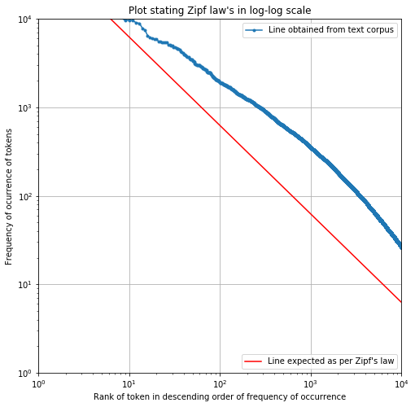

```python
plt.figure(figsize=(8,8))
plt.ylim(1,10**4)
plt.xlim(1,10**4)

#Actual ranks and frequencies
obtained_line, = loglog(ranks,freq, marker='.',label='Line obtained from text corpus' )
legend_line=plt.legend(handles=[obtained_line],loc=1)
ax=plt.gca().add_artist(legend_line)

# Expected ranks and frequencies as per Zipf's law
expect_line,=plt.plot([1,freq[0]],[freq[0],1],color='r',label="Line expected as per Zipf's law")
plt.legend(handles=[expect_line],loc=4)

title("Plot stating Zipf law's in log-log scale")
xlabel("Rank of token in descending order of frequency of occurrence")
ylabel("Frequency of ocurrence of tokens")
grid(True)
```

## TF-IDF (Term-Frequency - Inverse Document Frequency)

```python
from sklearn.feature_extraction.text import TfidfVectorizer
```

```python
corpus2=['Data science is an overlap between Arts and Science',
        'Generally, Arts graduates are right-brained and Science graduates are left-brained',
        'Excelling in both Arts and Science at a time becomes difficult',
        'Natural Language Processing is a part of Data Science']
```

```python
tfidf=TfidfVectorizer()
tfidf_df=tfidf.fit_transform(corpus2).todense()
print(tfidf_df)
# Tf-IDF representation of corpus in matrix form
```

```
[[0.40332811 0.25743911 0.         0.25743911 0.         0.
  0.40332811 0.         0.         0.31798852 0.         0.
  0.         0.         0.         0.31798852 0.         0.
  0.         0.         0.40332811 0.         0.         0.
  0.42094668 0.        ]
 [0.         0.159139   0.49864399 0.159139   0.         0.
  0.         0.         0.49864399 0.         0.         0.
  0.24932199 0.49864399 0.         0.         0.         0.24932199
  0.         0.         0.         0.         0.         0.24932199
  0.13010656 0.        ]
 [0.         0.22444946 0.         0.22444946 0.35164346 0.35164346
  0.         0.35164346 0.         0.         0.35164346 0.35164346
  0.         0.         0.35164346 0.         0.         0.
  0.         0.         0.         0.         0.         0.
  0.18350214 0.35164346]
 [0.         0.         0.         0.         0.         0.
  0.         0.         0.         0.30887228 0.         0.
  0.         0.         0.         0.30887228 0.39176533 0.
  0.39176533 0.39176533 0.         0.39176533 0.39176533 0.
  0.2044394  0.        ]]
```

```python
# Create a function that returns dataframe in frequent terms.
def tfid_df(corpus):
    tfidf_df=pd.DataFrame(tfidf.fit_transform(corpus2).todense())
    tfidf_df.columns=(sorted(tfidf.vocabulary_))
    return tfidf_df

# Create a function that returns 10 most frequent terms.
def tf_idf_matrix(corpus):
    tfidf_feat=TfidfVectorizer(max_features=10)
    feat_df=pd.DataFrame(tfidf_feat.fit_transform(corpus).todense())
    feat_df.columns=sorted(tfidf_feat.vocabulary_)
    return feat_df
```

```python
tfid_df(corpus1)
```

|  | an | and | are | arts | at | becomes | between | both | brained | data | ... | language | left | natural | of | overlap | part | processing | right | science | time |
| --- | --- | --- | --- | --- | --- | --- | --- | --- | --- | --- | --- | --- | --- | --- | --- | --- | --- | --- | --- | --- | --- |
| 0 | 0.403328 | 0.257439 | 0.000000 | 0.257439 | 0.000000 | 0.000000 | 0.403328 | 0.000000 | 0.000000 | 0.317989 | ... | 0.000000 | 0.000000 | 0.000000 | 0.000000 | 0.403328 | 0.000000 | 0.000000 | 0.000000 | 0.420947 | 0.000000 |
| 1 | 0.000000 | 0.159139 | 0.498644 | 0.159139 | 0.000000 | 0.000000 | 0.000000 | 0.000000 | 0.498644 | 0.000000 | ... | 0.000000 | 0.249322 | 0.000000 | 0.000000 | 0.000000 | 0.000000 | 0.000000 | 0.249322 | 0.130107 | 0.000000 |
| 2 | 0.000000 | 0.224449 | 0.000000 | 0.224449 | 0.351643 | 0.351643 | 0.000000 | 0.351643 | 0.000000 | 0.000000 | ... | 0.000000 | 0.000000 | 0.000000 | 0.000000 | 0.000000 | 0.000000 | 0.000000 | 0.000000 | 0.183502 | 0.351643 |
| 3 | 0.000000 | 0.000000 | 0.000000 | 0.000000 | 0.000000 | 0.000000 | 0.000000 | 0.000000 | 0.000000 | 0.308872 | ... | 0.391765 | 0.000000 | 0.391765 | 0.391765 | 0.000000 | 0.391765 | 0.391765 | 0.000000 | 0.204439 | 0.000000 |

4 rows × 26 columns

```python
tf_idf_matrix(corpus1)
```

|  | 000 | 10 | approach | at | is | of | standard | step | steps | the |
| --- | --- | --- | --- | --- | --- | --- | --- | --- | --- | --- |
| 0 | 0.211983 | 0.211983 | 0.000000 | 0.000000 | 0.259286 | 0.320270 | 0.406222 | 0.406222 | 0.000000 | 0.640540 |
| 1 | 0.323468 | 0.323468 | 0.000000 | 0.488704 | 0.395648 | 0.488704 | 0.000000 | 0.000000 | 0.395648 | 0.000000 |
| 2 | 0.534822 | 0.534822 | 0.000000 | 0.000000 | 0.000000 | 0.000000 | 0.000000 | 0.000000 | 0.654164 | 0.000000 |
| 3 | 0.274934 | 0.274934 | 0.526853 | 0.415377 | 0.336283 | 0.000000 | 0.000000 | 0.000000 | 0.336283 | 0.415377 |

# Extracting specific Features from 20newsgroups

```python
from sklearn.datasets import fetch_20newsgroups
```

```python
news=fetch_20newsgroups(subset='train')
```

```python
news['data'][9]
```

```
"From: kerr@ux1.cso.uiuc.edu (Stan Kerr)\nSubject: Re: Sigma Designs Double up??\nArticle-I.D.: ux1.C52u8x.B62\nOrganization: University of Illinois at Urbana\nLines: 29\n\njap10@po.CWRU.Edu (Joseph A. Pellettiere) writes:\n\n\n>\tI am looking for any information about the Sigma Designs\n>\tdouble u…
```

```python
import pandas as pd
from string import punctuation
from nltk.corpus import stopwords
punc=punctuation
stop_words = set(stopwords.words('english'))
from nltk.stem import WordNetLemmatizer
from nltk import word_tokenize
import re
from sklearn.feature_extraction.text import CountVectorizer
from sklearn.feature_extraction.text import TfidfVectorizer
```

```python
news
```

```python
news_df=pd.DataFrame(news['data'])
news_df.columns=['Text']
```

```python
news_df['Text'].iloc[8]
```

```
'From: holmes7000@iscsvax.uni.edu\nSubject: WIn 3.0 ICON HELP PLEASE!\nOrganization: University of Northern Iowa\nLines: 10\n\nI have win 3.0 and downloaded several icons and BMP\'s but I can\'t figure out\nhow to change the "wallpaper" or use the icons.  Any help would be appreciated.\n\n\nThanx,\n…
```

```python
news_df.info()
```

```
<class 'pandas.core.frame.DataFrame'>
RangeIndex: 11314 entries, 0 to 11313
Data columns (total 1 columns):
Text    11314 non-null object
dtypes: object(1)
memory usage: 88.5+ KB
```

```python
lemmat = WordNetLemmatizer()
```

```python
## Remove all punctations and stop-words and lower letters

news_df['clean_text']=news_df['Text'].apply(lambda x: ' '.join(lemmat.lemmatize(word.lower())\
                                                               for word in word_tokenize(re.sub(r'([^\s\w]|_)+', ' ',str(x)))\
                                                              if word.lower() not in stop_words))
```

```python
news_df['clean_text'].iloc[3]
```

```
'jgreen amber joe green subject weitek p9000 organization harris computer system division line 14 distribution world nntp posting host amber ssd csd harris com x newsreader tin version 1 1 pl9 robert j c kyanko rob rjck uucp wrote abraxis iastate edu writes article abraxis 734340159 class1 iastate e…
```

```python
## Create a BoW model
def bow_model(doc):
    bowmodel=CountVectorizer(max_features=20)
    bow_df=pd.DataFrame(bowmodel.fit_transform(doc).todense())
    bow_df.columns=sorted(bowmodel.vocabulary_)
    return bow_df
```

```python
bow_model(news_df['clean_text']).head()
```

|  | article | ax | com | edu | get | host | know | like | line | max | nntp | one | organization | people | posting | subject | time | university | would | writes |
| --- | --- | --- | --- | --- | --- | --- | --- | --- | --- | --- | --- | --- | --- | --- | --- | --- | --- | --- | --- | --- |
| 0 | 0 | 0 | 0 | 2 | 0 | 1 | 1 | 0 | 1 | 0 | 1 | 0 | 1 | 0 | 1 | 1 | 0 | 1 | 0 | 0 |
| 1 | 1 | 0 | 0 | 3 | 0 | 1 | 0 | 0 | 1 | 0 | 1 | 0 | 1 | 0 | 1 | 1 | 0 | 1 | 0 | 0 |
| 2 | 0 | 0 | 0 | 2 | 1 | 0 | 1 | 1 | 2 | 0 | 0 | 1 | 1 | 1 | 0 | 1 | 1 | 1 | 0 | 0 |
| 3 | 1 | 0 | 2 | 2 | 1 | 1 | 1 | 1 | 1 | 0 | 1 | 0 | 1 | 0 | 1 | 1 | 0 | 0 | 0 | 1 |
| 4 | 2 | 0 | 2 | 3 | 0 | 0 | 0 | 0 | 1 | 0 | 0 | 0 | 1 | 0 | 0 | 1 | 0 | 0 | 0 | 1 |

```python
## Create a TF-IDF model
def tfidf_model(doc):
    tfidf_feat=TfidfVectorizer(max_features=10)
    feat_df=pd.DataFrame(tfidf_feat.fit_transform(doc).todense())
    feat_df.columns=sorted(tfidf_feat.vocabulary_)
    return feat_df
```

```python
tfidf_model(news_df['clean_text']).head()
```

|  | article | ax | com | edu | line | one | organization | subject | would | writes |
| --- | --- | --- | --- | --- | --- | --- | --- | --- | --- | --- |
| 0 | 0.000000 | 0.0 | 0.000000 | 0.851389 | 0.299482 | 0.000000 | 0.310262 | 0.298637 | 0.0 | 0.000000 |
| 1 | 0.353720 | 0.0 | 0.000000 | 0.865214 | 0.202897 | 0.000000 | 0.210200 | 0.202324 | 0.0 | 0.000000 |
| 2 | 0.000000 | 0.0 | 0.000000 | 0.673213 | 0.473615 | 0.454449 | 0.245331 | 0.236139 | 0.0 | 0.000000 |
| 3 | 0.314466 | 0.0 | 0.668902 | 0.512799 | 0.180381 | 0.000000 | 0.186873 | 0.179871 | 0.0 | 0.301506 |
| 4 | 0.493319 | 0.0 | 0.524670 | 0.603340 | 0.141486 | 0.000000 | 0.146579 | 0.141087 | 0.0 | 0.236494 |

## Feature Engineering

- Two popular methods:
- (1) Cosine similarity: Between 2 texts is the cosine of the angle between their vector representations.(ex. BoW & TFIDF)
- (2) Jacard similarity: The ratio of the number of terms common between 2 text documents to the total num of unique terms present in those text.

```python
lemmat=WordNetLemmatizer()
```

```python
pair1=['What you do defines you','Your deeds define you']
pair2=['Once upon a time there lived king','Who is your queen?']
pair3=['He is desperate','Is he not desperate']
```

```python
# Create a function to extract the Jaccard similarity between a pair of sentences.
def Jaccard_sim(text1, text2):
    word1=[lemmat.lemmatize(w.lower()) for w in word_tokenize(text1)]
    word2=[lemmat.lemmatize(w.lower()) for w in word_tokenize(text2)]

    nr=len(set(word1).intersection(set(word2)))
    dr=len(set(word1).union(set(word2)))
    jaccard=nr/dr
    return jaccard
```

```python
# Check simularity between pair 1
Jaccard_sim(pair1[0],pair1[1]), Jaccard_sim(pair2[0],pair2[1]), Jaccard_sim(pair3[0],pair3[1])
```

```
(0.14285714285714285, 0.0, 0.75)
```

```python
# Check cosine simularity
cosine_sim=TfidfVectorizer()
pair_corpus=[pair1[0],pair1[1], pair2[0],pair2[1], pair3[0],pair3[1]]
```

```python
cosine_res=cosine_sim.fit_transform(pair_corpus).todense()
```

```python
cosine_similarity(cosine_res[0],cosine_res[1])
```

```
array([[0.3082764]])
```

```python
cosine_similarity(cosine_res[2],cosine_res[3])
```

```
array([[0.]])
```

```python
cosine_similarity(cosine_res[4],cosine_res[5])
```

```
array([[0.80368547]])
```

# Text Visualization: Word Clouds & Spacy

Word clouds is a visualization of the text corpus in which the sizes of tokens(words) represent the number of times they occurs

```python
import matplotlib.pyplot as plt
%matplotlib inline
from sklearn.datasets import fetch_20newsgroups
news_data=fetch_20newsgroups(subset='train')
from wordcloud import WordCloud, STOPWORDS
```

```python
news_data['data'][:10]
```

```
["From: lerxst@wam.umd.edu (where's my thing)\nSubject: WHAT car is this!?\nNntp-Posting-Host: rac3.wam.umd.edu\nOrganization: University of Maryland, College Park\nLines: 15\n\n I was wondering if anyone out there could enlighten me on this car I saw\nthe other day. It was a 2-door sports car, look…
 "From: guykuo@carson.u.washington.edu (Guy Kuo)\nSubject: SI Clock Poll - Final Call\nSummary: Final call for SI clock reports\nKeywords: SI,acceleration,clock,upgrade\nArticle-I.D.: shelley.1qvfo9INNc3s\nOrganization: University of Washington\nLines: 11\nNNTP-Posting-Host: carson.u.washington.edu\…
 'From: twillis@ec.ecn.purdue.edu (Thomas E Willis)\nSubject: PB questions...\nOrganization: Purdue University Engineering Computer Network\nDistribution: usa\nLines: 36\n\nwell folks, my mac plus finally gave up the ghost this weekend after\nstarting life as a 512k way back in 1985.  sooo, i\'m in …
 'From: jgreen@amber (Joe Green)\nSubject: Re: Weitek P9000 ?\nOrganization: Harris Computer Systems Division\nLines: 14\nDistribution: world\nNNTP-Posting-Host: amber.ssd.csd.harris.com\nX-Newsreader: TIN [version 1.1 PL9]\n\nRobert J.C. Kyanko (rob@rjck.UUCP) wrote:\n> abraxis@iastate.edu writes i…
 'From: jcm@head-cfa.harvard.edu (Jonathan McDowell)\nSubject: Re: Shuttle Launch Question\nOrganization: Smithsonian Astrophysical Observatory, Cambridge, MA,  USA\nDistribution: sci\nLines: 23\n\nFrom article <C5owCB.n3p@world.std.com>, by tombaker@world.std.com (Tom A Baker):\n>>In article <C5JLw…
 'From: dfo@vttoulu.tko.vtt.fi (Foxvog Douglas)\nSubject: Re: Rewording the Second Amendment (ideas)\nOrganization: VTT\nLines: 58\n\nIn article <1r1eu1$4t@transfer.stratus.com> cdt@sw.stratus.com (C. D. Tavares) writes:\n>In article <1993Apr20.083057.16899@ousrvr.oulu.fi>, dfo@vttoulu.tko.vtt.fi (F…
 'From: bmdelane@quads.uchicago.edu (brian manning delaney)\nSubject: Brain Tumor Treatment (thanks)\nReply-To: bmdelane@midway.uchicago.edu\nOrganization: University of Chicago\nLines: 12\n\nThere were a few people who responded to my request for info on\ntreatment for astrocytomas through email, w…
 'From: bgrubb@dante.nmsu.edu (GRUBB)\nSubject: Re: IDE vs SCSI\nOrganization: New Mexico State University, Las Cruces, NM\nLines: 44\nDistribution: world\nNNTP-Posting-Host: dante.nmsu.edu\n\nDXB132@psuvm.psu.edu writes:\n>In article <1qlbrlINN7rk@dns1.NMSU.Edu>, bgrubb@dante.nmsu.edu (GRUBB) says:…
 'From: holmes7000@iscsvax.uni.edu\nSubject: WIn 3.0 ICON HELP PLEASE!\nOrganization: University of Northern Iowa\nLines: 10\n\nI have win 3.0 and downloaded several icons and BMP\'s but I can\'t figure out\nhow to change the "wallpaper" or use the icons.  Any help would be appreciated.\n\n\nThanx,\…
 "From: kerr@ux1.cso.uiuc.edu (Stan Kerr)\nSubject: Re: Sigma Designs Double up??\nArticle-I.D.: ux1.C52u8x.B62\nOrganization: University of Illinois at Urbana\nLines: 29\n\njap10@po.CWRU.Edu (Joseph A. Pellettiere) writes:\n\n\n>\tI am looking for any information about the Sigma Designs\n>\tdouble …
```

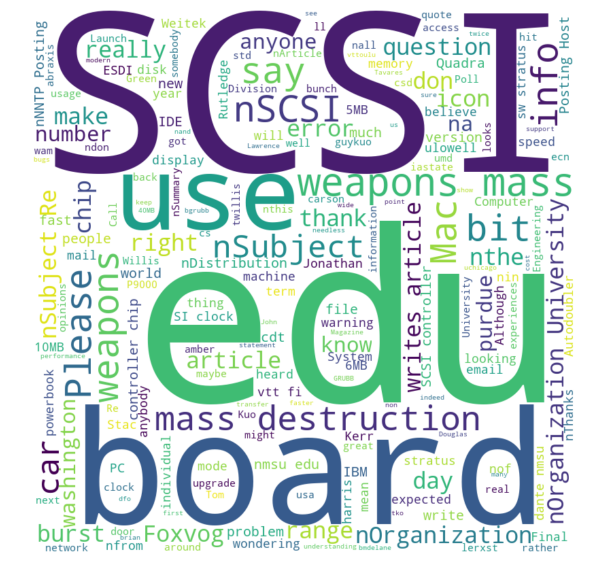

```python
other_stopwd=['\\n','n','\\','>','nLines','nI',"n'"]
STOPWORDS=STOPWORDS.union(set(other_stopwd))
stopwords=set(STOPWORDS)
text=str(news_data['data'][:10])
wordclouds=WordCloud(width=800, height=800, background_color='white',
                     max_words=200,stopwords=stopwords, min_font_size=10).generate(text)
plt.figure(figsize=(10,10))
plt.imshow(wordclouds,interpolation='bilinear')
plt.axis('off')
plt.show()
```

```python
import spacy
from spacy import displacy
nlp = spacy.load('en_core_web_sm')
```

```python
text=nlp(u'The Collapsing Crime Rates of the ’90s Might Have Been Driven by Cellphones.')
```

```python
displacy.render(text,style='dep',jupyter=True)
```

[figure not shown]

```python
text2=nlp(u"Syria accused Israel of targeting an airbase in Homs province, reportedly killing five people, just hours after carrying out retaliatory attacks on military and intelligence posts south of Damascus, killing 10.")
displacy.render(text2, style='ent',jupyter=True)
```

Syria GPE accused Israel GPE of targeting an airbase in Homs province GPE , reportedly killing five CARDINAL people, just hours TIME after carrying out retaliatory attacks on military and intelligence posts south of Damascus GPE , killing 10 CARDINAL .

# Activity 4: Text Visualization

```python
from wordcloud import WordCloud, STOPWORDS
import matplotlib.pyplot as plt
%matplotlib inline
from nltk import word_tokenize
from nltk.stem import WordNetLemmatizer
import nltk
from collections import Counter
import re
```

```python
with open('data_ch2/text_corpus.txt', 'r') as f:
    doc=f.read()
```

```python
print(doc)
```

[output not shown]

[output cut: 323 more lines]

```
Spend actually worker show message reduce stuff. Speech thus quickly million blood candidate. Military arrive now however.
Green situation admit other artist. Happy ahead bring view.
Weight heavy although short threat should level feel. Early perhaps light benefit where authority at.
Institution next impact public. They our apply think husband information past.
Part example across his recent. Executive office appear. Determine live public page difficult truth stop.Enjoy prevent watch generation color study however plan. Can thought you option partner new. Whose lot simple professor down woman.
Establish certainly goal language watch land.
Him everyone these environment spend buy build several. I maintain mother south hand assume cell several. Total start value price.
Big true could network. Seek account part list market his.
Cup sea loss movement identify sort own. Minute surface blood memory summer them. Under item national against suggest conference management.
Night civil matter animal not way gas.
Much majority firm special. It pick poor structure major.
In six crime cause major. Itself sure guess under. When southern movement newspaper.
Theory boy name. Industry accept behavior size especially reduce provide.
Difficult everybody wide could television structure clear. Tv data short start treatment high safe.
Foreign simply ask discuss training. Kind especially her. Meeting music some run.
```

```python
nltk.download('wordnet')
```

```
True
```

```python
## Create a Function to pre-process steps: text cleaning, tokenization,stop-word removal, lemmatization.
def clean_docu(text):
    return [lemmat.lemmatize(word.lower())for word in word_tokenize(re.sub(r'([^\s\w]|_)+', ' ', text))\
                                                              if word.lower() not in stop_words]
```

```python
clean_text=clean_docu(doc)
print(clean_text)
```

```
['control', 'role', 'kind', 'exist', 'front', 'security', 'mr', 'picture', 'example', 'season', 'side', 'dog', 'outside', 'home', 'house', 'participant', 'cultural', 'minute', 'wait', 'time', 'network', 'suddenly', 'property', 'skin', 'represent', 'long', 'board', 'including', 'generation', 'technol…
```

```python
# Display the most 50 common words in document
Counter(clean_text).most_common(50)
```

```
[('program', 14),
 ('effect', 14),
 ('choice', 14),
 ('account', 13),
 ('way', 13),
 ('democrat', 13),
 ('television', 13),
 ('gun', 13),
 ('outside', 12),
 ('key', 12),
 ('sea', 12),
 ('office', 12),
 ('factor', 12),
 ('business', 12),
 ('study', 12),
 ('identify', 11),
 ('recently', 11),
 ('happy', 11),
 ('left', 11),
 ('final', 11),
 ('option', 11),
 ('everyone', 11),
 ('moment', 11),
 ('century', 11),
 ('lose', 11),
 ('discussion', 11),
 ('sing', 11),
 ('write', 11),
 ('mention', 11),
 ('well', 11),
 ('could', 11),
 ('night', 11),
 ('side', 10),
 ('language', 10),
 ('question', 10),
 ('energy', 10),
 ('also', 10),
 ('staff', 10),
 ('several', 10),
 ('able', 10),
 ('major', 10),
 ('either', 10),
 ('goal', 10),
 ('manage', 10),
 ('modern', 10),
 ('art', 10),
 ('partner', 10),
 ('president', 10),
 ('maybe', 10),
 ('different', 10)]
```

[figure not shown]

```python
stopwords=set(STOPWORDS)
clean_text=' '.join(clean_text)
wordclouds=WordCloud(width=800, height=800, background_color='white',\
                     max_words=200,stopwords=stopwords, min_font_size=10).generate(clean_text)

plt.figure(figsize=(10,10))
plt.imshow(wordclouds,interpolation='bilinear')
plt.axis('off')
plt.show()
```